# Exploratory Data Analysis of Processed HC Corpora

KevinHo

11 April 2017

The first step is to make a corpus for our use. Rather than process the entire corpus we can randomly sample the data to get a fairly accurate representation. This requires a sample files to be generated

10% of the original corpus will be taken as a sample

```
## [1] "Saved 7700 lines to file. ../../Temp/Data-Science-Specialization-Capstone-Data/Sampled/news/en_US.news_Sampled.txt"
```

```
## [1] "Saved 90003 lines to file. ../../Temp/Data-Science-Specialization-Capstone-Data/Sampled/blogs/en_US.blogs_Sampled.txt"
```

```
## [1] "Saved 236302 lines to file. ../../Temp/Data-Science-Specialization-Capstone-Data/Sampled/twitter/en_US.twitter_Sampled.txt"
```

## Source Data Analysis

Lets analyse each of the corpora individually to see if there are specific characteristics of each one. The folowing process also processes the corpora. It will leave only latin characters. All words are defined as continuous string of chracters without whitespaces. All punctuation and stopwords have been removed.

Because of this processing the problems of foreign words, typos and predicting the next word past a stop word still remain.

```r
docs.twitter <- make.TMMap("C:/Users/Kevin/Documents/GitHub/Temp/Data-Science-Specialization-Capstone-Data/Sampled/twitter")
docs.blogs <- make.TMMap("C:/Users/Kevin/Documents/GitHub/Temp/Data-Science-Specialization-Capstone-Data/Sampled/blogs")
docs.news <- make.TMMap("C:/Users/Kevin/Documents/GitHub/Temp/Data-Science-Specialization-Capstone-Data/Sampled/news")
```

First we create Document Term Matricies for easier analysis

```r
dtm.twitter <- DocumentTermMatrix(docs.twitter)
dtm.news <- DocumentTermMatrix(docs.news)
dtm.blogs <- DocumentTermMatrix(docs.blogs)
```

Lets have a look at the most frequent 20 terms of each dataset

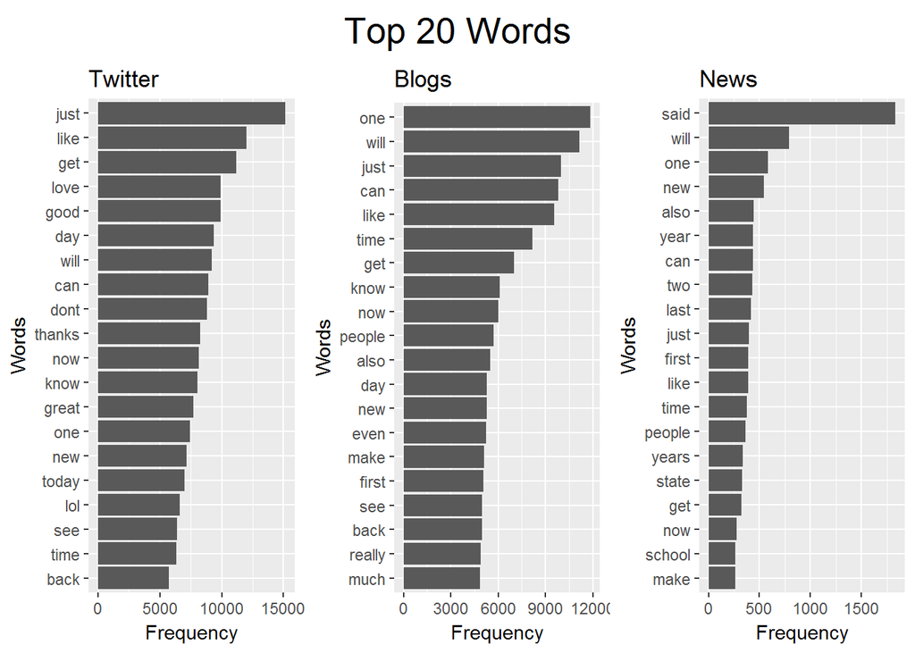

```r
dtm.twitter.freq <- tbl_df(data.frame(Words = dtm.twitter$dimnames$Terms, Frequency = colSums(as.matrix(dtm.twitter))))
dtm.news.freq <- tbl_df(data.frame(Words = dtm.news$dimnames$Terms, Frequency = colSums(as.matrix(dtm.news))))
dtm.blogs.freq <- tbl_df(data.frame(Words = dtm.blogs$dimnames$Terms, Frequency = colSums(as.matrix(dtm.blogs))))

dtm.twitter.freq.top <- dtm.twitter.freq %>%
                        top_n(20)

dtm.news.freq.top <- dtm.news.freq %>%
                top_n(20)

dtm.blogs.freq.top <- dtm.blogs.freq %>%
                top_n(20)

#Fun bit of code so that ggplot will display the words ordered by their value
dtm.twitter.freq.top$Words <- factor(dtm.twitter.freq.top$Words, levels = dtm.twitter.freq.top$Words)
dtm.twitter.freq.top$Words <- factor(dtm.twitter.freq.top$Words, levels = dtm.twitter.freq.top$Words[order(dtm.twitter.freq.top$Frequency)])

dtm.news.freq.top$Words <- factor(dtm.news.freq.top$Words, levels = dtm.news.freq.top$Words)
dtm.news.freq.top$Words <- factor(dtm.news.freq.top$Words, levels = dtm.news.freq.top$Words[order(dtm.news.freq.top$Frequency)])

dtm.blogs.freq.top$Words <- factor(dtm.blogs.freq.top$Words, levels = dtm.blogs.freq.top$Words)
dtm.blogs.freq.top$Words <- factor(dtm.blogs.freq.top$Words, levels = dtm.blogs.freq.top$Words[order(dtm.blogs.freq.top$Frequency)])

g1 <- ggplot(dtm.twitter.freq.top, aes(Words,Frequency)) + geom_bar(stat = "Identity") + coord_flip() + labs(title = "Twitter")
g2 <- ggplot(dtm.blogs.freq.top, aes(Words,Frequency)) + geom_bar(stat = "Identity") + coord_flip() + labs(title = "Blogs")
g3 <- ggplot(dtm.news.freq.top, aes(Words,Frequency)) + geom_bar(stat = "Identity") + coord_flip() + labs(title = "News")

multiplot(g1,g2,g3, cols=3, title = "Top 20 Words")
```

It can be seen from the sample that the twitter and blogs data will dominate the news data in any predictive counts.

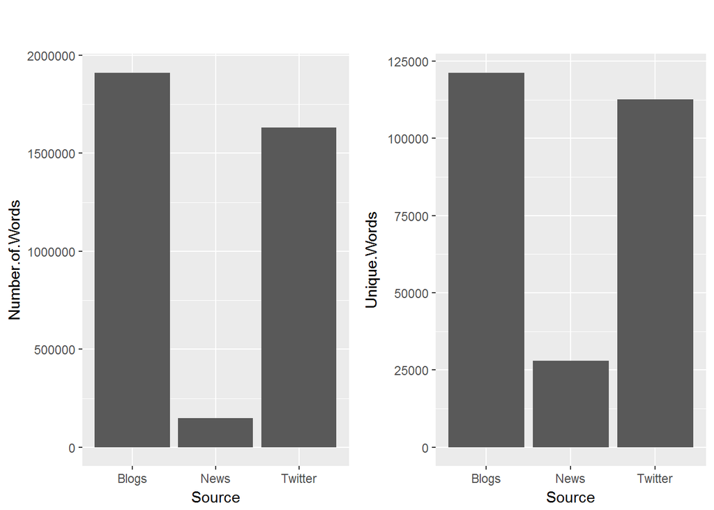

```r
uniqueWords <- data.frame("Source" = c("Twitter","Blogs","News"),
                          "Number of Words"= c(sum(dtm.twitter.freq$Frequency),sum(dtm.blogs.freq$Frequency),sum(dtm.news.freq$Frequency)),
                          "Unique Words"= c(nrow(dtm.twitter.freq),nrow(dtm.blogs.freq),nrow(dtm.news.freq)))

g1 <- ggplot(uniqueWords,aes(Source,Number.of.Words)) + geom_bar(stat = "Identity")
g2 <- ggplot(uniqueWords,aes(Source,Unique.Words)) + geom_bar(stat = "Identity")

multiplot(g1,g2, cols = 2)
```

Once again the news data will be under represented in any predictive tool based purely on counts.

## Analysis of the Corpus in N-grams

The aim of this project is to make an application that can take a phrase and predict the next most likely word. For example google search suggestions has a completion function. So when I type in “I want a” google offers the following suggestions

[figure not shown]

Google Search: “I want a”

This is the functionality we’d like to replicate.

```r
docs <- make.TMMap("C:/Users/Kevin/Documents/GitHub/Temp/Data-Science-Specialization-Capstone-Data/Sampled/")
```

And lets convert these documents into monograms, bigrams and trigrams.

```r
dtm.mono <- DocumentTermMatrix(docs)
dtm.bigram <- DocumentTermMatrix(docs, control = list(tokenize = BigramTokenizer))
dtm.trigram <- DocumentTermMatrix(docs, control = list(tokenize = TrigramTokenizer))
```

Lets have a look at the most frequent 20 terms of each dataset

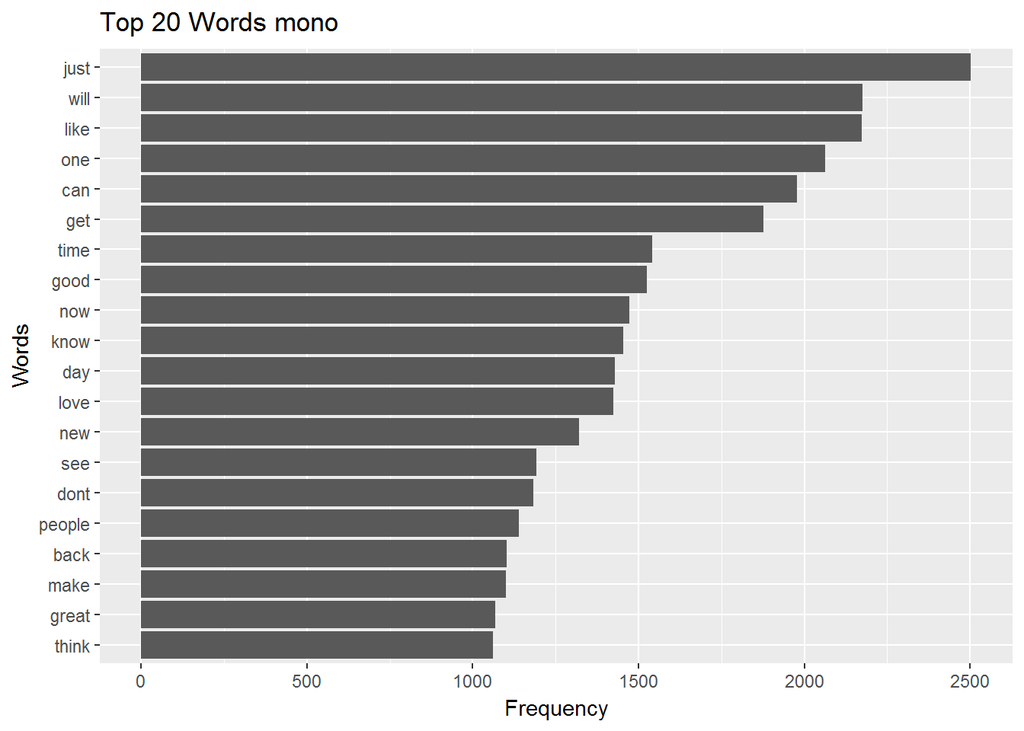

```r
dtm.mono.freq <- tbl_df(data.frame(Words = dtm.mono$dimnames$Terms, Frequency = colSums(as.matrix(dtm.mono)))) %>%
    arrange(desc(Frequency)) %>%
    mutate(cumsum = cumsum(Frequency)) %>%
    mutate(coverage = cumsum/sum(Frequency))

dtm.bigram.freq <- tbl_df(data.frame(Words = dtm.bigram$dimnames$Terms, Frequency = colSums(as.matrix(dtm.bigram)))) %>%
    arrange(desc(Frequency)) %>%
    mutate(cumsum = cumsum(Frequency)) %>%
    mutate(coverage = cumsum/sum(Frequency))

dtm.trigram.freq <- tbl_df(data.frame(Words = dtm.trigram$dimnames$Terms, Frequency = colSums(as.matrix(dtm.trigram)))) %>%
    arrange(desc(Frequency)) %>%
    mutate(cumsum = cumsum(Frequency)) %>%
    mutate(coverage = cumsum/sum(Frequency))

dtm.mono.freq.top <- dtm.mono.freq %>%
                        top_n(20,Frequency)

dtm.bigram.freq.top <- dtm.bigram.freq %>%
                top_n(20,Frequency)

dtm.trigram.freq.top <- dtm.trigram.freq %>%
                top_n(20,Frequency)

#Fun bit of code so that ggplot will display the words ordered by their value
dtm.mono.freq.top$Words <- factor(dtm.mono.freq.top$Words, levels = dtm.mono.freq.top$Words)
dtm.mono.freq.top$Words <- factor(dtm.mono.freq.top$Words, levels = dtm.mono.freq.top$Words[order(dtm.mono.freq.top$Frequency)])

dtm.bigram.freq.top$Words <- factor(dtm.bigram.freq.top$Words, levels = dtm.bigram.freq.top$Words)
dtm.bigram.freq.top$Words <- factor(dtm.bigram.freq.top$Words, levels = dtm.bigram.freq.top$Words[order(dtm.bigram.freq.top$Frequency)])

dtm.trigram.freq.top$Words <- factor(dtm.trigram.freq.top$Words, levels = dtm.trigram.freq.top$Words)
dtm.trigram.freq.top$Words <- factor(dtm.trigram.freq.top$Words, levels = dtm.trigram.freq.top$Words[order(dtm.trigram.freq.top$Frequency)])

g1 <- ggplot(dtm.mono.freq.top, aes(Words,Frequency)) + geom_bar(stat = "Identity") + coord_flip() + labs(title = "Top 20 Words mono")
g2 <- ggplot(dtm.bigram.freq.top, aes(Words,Frequency)) + geom_bar(stat = "Identity") + coord_flip() + labs(title = "Top 20 Words bigram")
g3 <- ggplot(dtm.trigram.freq.top, aes(Words,Frequency)) + geom_bar(stat = "Identity") + coord_flip() + labs(title = "Top 20 Words trigram")

g1
```

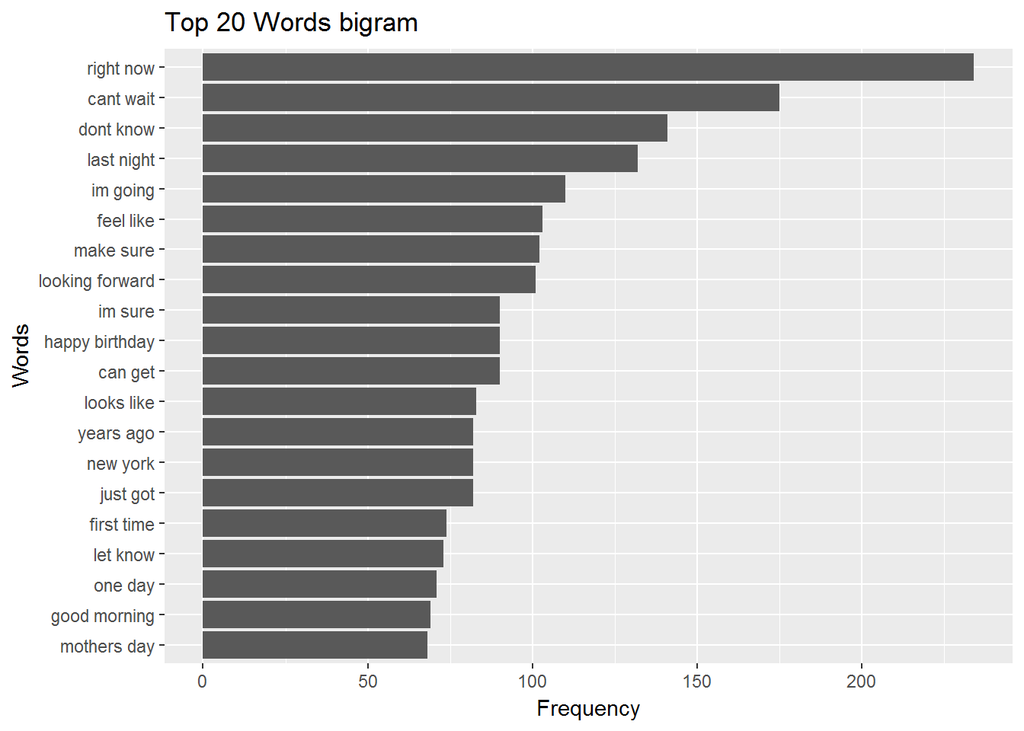

```r
g2
```

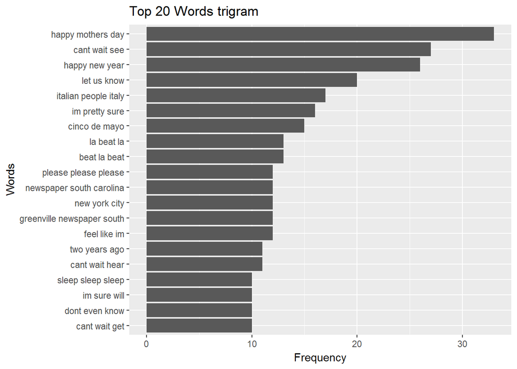

```r
g3
```

It can be seen from the sample that as the length of the terms grow. The non-unique terms reduce by roughly an order of magnitude. This means that the dictionary size will need to grow to maintain coverage. As shown below.

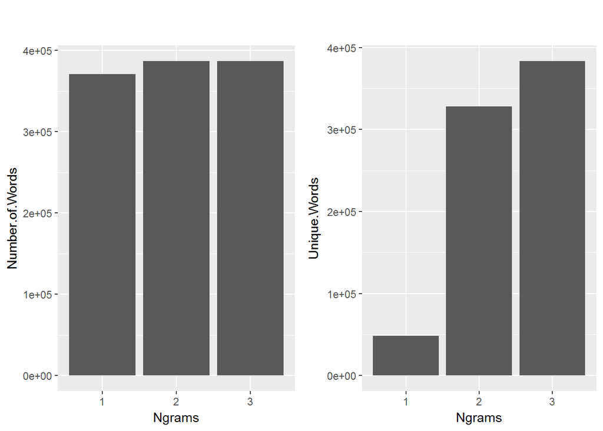

```r
uniqueWords <- data.frame("Ngrams" = c("1","2","3"),
                          "Number of Words"= c(sum(dtm.mono.freq$Frequency),sum(dtm.bigram.freq$Frequency),sum(dtm.trigram.freq$Frequency)),
                          "Unique Words"= c(nrow(dtm.mono.freq),nrow(dtm.bigram.freq),nrow(dtm.trigram.freq)))

g1 <- ggplot(uniqueWords,aes(Ngrams,Number.of.Words)) + geom_bar(stat = "Identity")
g2 <- ggplot(uniqueWords,aes(Ngrams,Unique.Words)) + geom_bar(stat = "Identity")

multiplot(g1,g2, cols = 2)
```

Conversely the number of unique terms grow as the Ngrams get larger.

## Coverage analysis of N-Grams

Given the number of unique terms the following table shows how many terms are required to be included in the dictionary to cover 50% and 90% of terms used.

```r
kable(
    tbl_df(
        data.frame(Ngram = c(1,2,3),
            "Unique Words" = c(nrow(dtm.mono.freq),
                             nrow(dtm.bigram.freq),
                             nrow(dtm.trigram.freq)
                             ),
            "Fifty Percent" = c(nrow(dtm.mono.freq) - sum(dtm.mono.freq$coverage>.5),
                             nrow(dtm.bigram.freq) - sum(dtm.bigram.freq$coverage>.5),
                             nrow(dtm.trigram.freq) - sum(dtm.trigram.freq$coverage>.5)
                             ),
            "Ninety Percent" = c(nrow(dtm.mono.freq) - sum(dtm.mono.freq$coverage>.9),
                            nrow(dtm.bigram.freq) - sum(dtm.bigram.freq$coverage>.9),
                            nrow(dtm.trigram.freq) - sum(dtm.trigram.freq$coverage>.9)
                            )
                    )
        )
    ,
    caption = "Required dictionary size to attain % coverage",
    col.names = c("N-Gram","Unique Words", "50% Coverage","90% Coverage")
    )
```

Required dictionary size to attain % coverage

| N-Gram | Unique Words | 50% Coverage | 90% Coverage |
| --- | --- | --- | --- |
| 1 | 48294 | 861 | 15731 |
| 2 | 328170 | 134854 | 289506 |
| 3 | 383252 | 189938 | 344589 |

As observed in the table. As N gets large, the dictionary must also increase in size to attain suitable coverage. This may have storage and computational issues if the dictionary is too large.

By converting words into root words (infinitives) Coverage could increase. There is additional complexity in interpreting tense. eg should a word end in “er”, “ing”, “s,”ed" etc. and choosing the correct one would depend on the context of the sentence

# Appendix

File Sampling Function

```r
create.sampled.file <- function(inputFile, outputFile, fraction = samplePercentage) {
    #This function randomly samples lines from an inputFile and then exports it into an outputFile

    conn <- file(inputFile, "r")
    fileContents <- readLines(conn, encoding="UTF-16LE", skipNul = TRUE)
    nlines <- length(fileContents)
    close(conn)

    conn <- file(outputFile, "w")
    selection <- rbinom(nlines, 1, fraction)
    for(i in  1: nlines) {
        if (selection[i]==1) {cat( stringi::stri_trans_general(fileContents[i], "latin-ascii"), file=conn, sep = "\n")}
    }
    close(conn)

    paste("Saved", sum(selection), "lines to file.", outputFile)
}
```

Data sampling and cleaning functions

```r
cat(readLines('~/GitHub/Data-Science-Specialization-Capstone/Exploratory Data Analysis - Week 2/Text Mining.R'), sep = '\n')
```

```
create.sampled.file <- function(inputFile, outputFile, fraction = 0.001) {
    #This function randomly samples lines from an inputFile and then exports it into an outputFile

    conn <- file(inputFile, "r")
    fileContents <- readLines(conn)
    nlines <- length(fileContents)
    close(conn)

    conn <- file(outputFile, "w")
    selection <- rbinom(nlines, 1, fraction)
    for(i in  1: nlines) {
        if (selection[i]==1) {cat(fileContents[i], file=conn, sep = "\n")}
    }
    close(conn)

    paste("Saved", sum(selection), "lines to file.", outputFile)
}


make.TMMap <- function(dataLoc) {
    #This R function takes a directory of documents and returns a plaintext document map of 1-grams with profanity and filtering. It

    #LOAD PACKAGES
    #Needed <- c("tm", "SnowballCC", "RColorBrewer", "ggplot2", "wordcloud", "biclust", "cluster", "igraph", "fpc")
    #install.packages(Needed, dependencies=TRUE)
    #install.packages("Rcampdf", repos = "http://datacube.wu.ac.at/", type = "source")

    # setvariables
    cname <- file.path(dataLoc)

    #LOAD DATA
    library(tm)
    docs <- Corpus(DirSource(cname))

    profanity <- readLines("C:/Users/Kevin/Documents/GitHub/Temp/profanity.txt", encoding = "UTF-8")
    #Confirm all files are available

    # PREPROCESSING
    #I'm not here to predict punctuation. Although it is possible.
    docs <- tm_map(docs, removePunctuation)
```

[output cut: 24 more lines]

```
    #remove whitespace
    docs <- tm_map(docs, stripWhitespace)

    #Return a plain text document
    tm_map(docs, PlainTextDocument)
}


BigramTokenizer <-
    function(x)
        unlist(lapply(ngrams(words(x), 2), paste, collapse = " "), use.names = FALSE)

TrigramTokenizer <-
    function(x)
        unlist(lapply(ngrams(words(x), 3), paste, collapse = " "), use.names = FALSE)
```

Other helper functions. Including multiplot

```r
cat(readLines('~/GitHub/Data-Science-Specialization-Capstone/Exploratory Data Analysis - Week 2/helpers.R'), sep = '\n')
```

```
# Multiple plot function
#
# ggplot objects can be passed in ..., or to plotlist (as a list of ggplot objects)
# - cols:   Number of columns in layout
# - layout: A matrix specifying the layout. If present, 'cols' is ignored.
#
# If the layout is something like matrix(c(1,2,3,3), nrow=2, byrow=TRUE),
# then plot 1 will go in the upper left, 2 will go in the upper right, and
# 3 will go all the way across the bottom.
#
# This function has been sourced from http://www.cookbook-r.com/Graphs/Multiple_graphs_on_one_page_(ggplot2)/ 15/03/17

multiplot <- function(..., plotlist=NULL, file, cols=1, layout=NULL, title = NULL) {
    library(grid)

    # Make a list from the ... arguments and plotlist
    plots <- c(list(...), plotlist)

    numPlots = length(plots)

    # If layout is NULL, then use 'cols' to determine layout
    if (is.null(layout)) {
        # Make the panel
        # ncol: Number of columns of plots
        # nrow: Number of rows needed, calculated from # of cols
        layout <- matrix(seq(1, cols * ceiling(numPlots/cols)),
                         ncol = cols, nrow = ceiling(numPlots/cols))
    }

    if (numPlots==1) {
        print(plots[[1]])

    } else {
        # Set up the page
        grid.newpage()

        pushViewport(viewport(layout = grid.layout(nrow(layout) + 1, ncol(layout), heights = c(0.5, rep(5,nrow(layout))))))

        grid.text(title,vp = viewport(layout.pos.row = 1, layout.pos.col = seq(1:ncol(layout))),gp=gpar(fontsize=20))

        # Make each plot, in the correct location
        for (i in 1:numPlots) {
            # Get the i,j matrix positions of the regions that contain this subplot
            matchidx <- as.data.frame(which(layout == i, arr.ind = TRUE))

            print(plots[[i]], vp = viewport(layout.pos.row = matchidx$row + 1,
                                            layout.pos.col = matchidx$col))
        }
    }
}
```